# Flow & Temperature Annual QC

Published

October 8, 2026

```r
library(tidyverse)
library(lubridate)
library(here)
library(glue)
library(DT)

if (file.exists(here::here("DESCRIPTION"))) {
  devtools::load_all(here::here(), quiet = TRUE)
} else {
  library(SRJPEdata)
}

source(here::here("data-raw", "qc", "qc_helpers.R"))

review_run_year <- params$review_run_year

EXPECTED_STREAMS <- c(
  "battle creek", "butte creek", "clear creek", "deer creek",
  "feather river", "mill creek", "sacramento river", "yuba river"
)

# RST season weeks (BTSPAS window: weeks 45-53 then 1-22)
RST_WEEKS <- c(45:53, 1:22)
```

## Overview

Reviewing flow and temperature data. Run year being reviewed: **2026**.

Data source: `flow_data` & `temperature_data` — weekly data with columns `year`, `week`, `stream`, `site_group`, `parameter`, `statistic`, `value`.

Environmental data coverage by stream, parameter, and statistic

| stream | parameter | statistic | min_year | max_year | n_records |
| --- | --- | --- | --- | --- | --- |
| battle creek | flow | max | 1990 | 2026 | 1920 |
| battle creek | flow | mean | 1990 | 2026 | 1920 |
| battle creek | flow | min | 1990 | 2026 | 1920 |
| battle creek | temperature | max | 2003 | 2026 | 1210 |
| battle creek | temperature | mean | 2003 | 2026 | 1210 |
| battle creek | temperature | min | 2003 | 2026 | 1210 |
| butte creek | flow | max | 1990 | 2026 | 1928 |
| butte creek | flow | mean | 1990 | 2026 | 1928 |
| butte creek | flow | min | 1990 | 2026 | 1928 |
| butte creek | temperature | max | 1998 | 2026 | 1484 |
| butte creek | temperature | mean | 1998 | 2026 | 1483 |
| butte creek | temperature | min | 1998 | 2026 | 1483 |
| clear creek | flow | max | 1990 | 2026 | 1927 |
| clear creek | flow | mean | 1990 | 2026 | 1927 |
| clear creek | flow | min | 1990 | 2026 | 1927 |
| clear creek | temperature | max | 2001 | 2025 | 2404 |
| clear creek | temperature | mean | 2001 | 2025 | 2404 |
| clear creek | temperature | min | 2001 | 2025 | 2404 |
| deer creek | flow | max | 1990 | 2026 | 1929 |
| deer creek | flow | mean | 1990 | 2026 | 1929 |
| deer creek | flow | min | 1990 | 2026 | 1929 |
| deer creek | temperature | max | 1998 | 2026 | 1480 |
| deer creek | temperature | mean | 1998 | 2026 | 1482 |
| deer creek | temperature | min | 1998 | 2026 | 1482 |
| feather river | flow | max | 1991 | 2026 | 4681 |
| feather river | flow | mean | 1991 | 2026 | 4681 |
| feather river | flow | min | 1991 | 2026 | 4681 |
| feather river | temperature | max | 1998 | 2026 | 2912 |
| feather river | temperature | mean | 1998 | 2026 | 2911 |
| feather river | temperature | min | 1998 | 2026 | 2972 |
| mill creek | flow | max | 1990 | 2026 | 1922 |
| mill creek | flow | mean | 1990 | 2026 | 1922 |
| mill creek | flow | min | 1990 | 2026 | 1922 |
| mill creek | temperature | max | 1998 | 2026 | 1485 |
| mill creek | temperature | mean | 1998 | 2026 | 1485 |
| mill creek | temperature | min | 1998 | 2026 | 1485 |
| sacramento river | flow | max | 1990 | 2026 | 5782 |
| sacramento river | flow | mean | 1990 | 2026 | 5782 |
| sacramento river | flow | min | 1990 | 2026 | 5782 |
| sacramento river | temperature | max | 1966 | 2023 | 4639 |
| sacramento river | temperature | mean | 1966 | 2023 | 4638 |
| sacramento river | temperature | min | 1966 | 2023 | 4640 |
| yuba river | flow | max | 1990 | 2026 | 1825 |
| yuba river | flow | mean | 1990 | 2026 | 1825 |
| yuba river | flow | min | 1990 | 2026 | 1825 |
| yuba river | temperature | max | 1998 | 2026 | 1488 |
| yuba river | temperature | mean | 1998 | 2026 | 1488 |
| yuba river | temperature | min | 1998 | 2026 | 1488 |

## Check 1 (error): Stream Coverage

Verify all expected streams have flow data for the most recent run year in the dataset.

```r
current_run_year_data <- max(flow_data$run_year, na.rm = TRUE)

stream_coverage <- flow_data |>
  filter(run_year == current_run_year_data) |>
  group_by(stream) |>
  summarise(
    n_weeks  = n(),
    max_year = max(year),
    max_week = max(week[year == max(year)]),
    .groups  = "drop"
  )

missing_streams <- tibble(stream = EXPECTED_STREAMS) |>
  anti_join(stream_coverage, by = "stream")

new_missing_streams <- log_issues(
  missing_streams |>
    mutate(
      site        = NA_character_,
      run_year    = current_run_year_data,
      n_records   = 0L,
      data_type   = "flow",
      issue_type  = "gap",
      field       = "stream_coverage",
      severity    = "critical",
      alert_level = "error",
      description = glue("Stream '{stream}' has no flow data in run year {current_run_year_data}")
    )
)
```

```
  No issues detected for this check.
```

Flow coverage in run year 2026

| stream | present | n_weeks | last_obs |
| --- | --- | --- | --- |
| battle creek | Present | 50 | year 2026 week 41 |
| butte creek | Present | 50 | year 2026 week 41 |
| clear creek | Present | 50 | year 2026 week 41 |
| deer creek | Present | 50 | year 2026 week 41 |
| feather river | Present | 150 | year 2026 week 41 |
| mill creek | Present | 50 | year 2026 week 41 |
| sacramento river | Present | 150 | year 2026 week 41 |
| yuba river | Present | 50 | year 2026 week 41 |

All expected streams present.

## Check 2 (warning): Flow — Missing Weeks in RST Season Window

For each stream/run_year, count how many weeks in the BTSPAS window (weeks 45–53 and 1–22) are missing flow data. Flag run_years where >20% of the 31 possible window weeks are missing (`gap`) or where 3+ consecutive weeks are missing (`extended_gap`).

```r
# Helper: find max consecutive missing weeks given present weeks and expected weeks
max_consec_missing <- function(weeks_present, expected) {
  missing <- expected[!expected %in% weeks_present]
  if (length(missing) == 0L) return(0L)
  # For consecutive detection, treat the season as a linear sequence
  # Map to position in expected vector
  pos <- which(expected %in% missing)
  max(tabulate(cumsum(c(1L, diff(pos) != 1L))))
}

# Weeks present per stream/run_year (within RST window)
weeks_present <- flow_data |>
  filter(week %in% RST_WEEKS) |>
  group_by(stream, site_group, run_year) |>
  summarise(
    weeks_present   = list(week),
    n_present       = n(),
    .groups         = "drop"
  ) |>
  mutate(
    n_expected       = 31L,  # weeks 45-53 (9) + 1-22 (22)
    n_missing        = n_expected - n_present,
    pct_missing      = round(n_missing / n_expected * 100, 1),
    max_consec       = map_int(weeks_present, ~max_consec_missing(.x, RST_WEEKS))
  )

gap_issues     <- weeks_present |> filter(pct_missing > 20, max_consec < 3)
ext_gap_issues <- weeks_present |> filter(max_consec >= 3)

new_gaps <- log_issues(
  gap_issues |>
    mutate(
      site        = site_group,
      data_type   = "flow",
      issue_type  = "gap",
      field       = "week",
      n_records   = n_missing,
      severity    = "moderate",
      alert_level = "warning",
      description = glue("{n_missing} of 31 RST window weeks ({pct_missing}%) missing flow data in run year {run_year} for {stream}")
    )
)
```

```
  No issues detected for this check.
```

```r
new_ext_gaps <- log_issues(
  ext_gap_issues |>
    mutate(
      site        = site_group,
      data_type   = "flow",
      issue_type  = "extended_gap",
      field       = "week",
      n_records   = max_consec,
      severity    = "critical",
      alert_level = "warning",
      description = glue("{max_consec} consecutive RST window weeks missing flow data in run year {run_year} for {stream} ({n_missing} total missing weeks)")
    )
)
```

```
  All 24 issue(s) already in log.
```

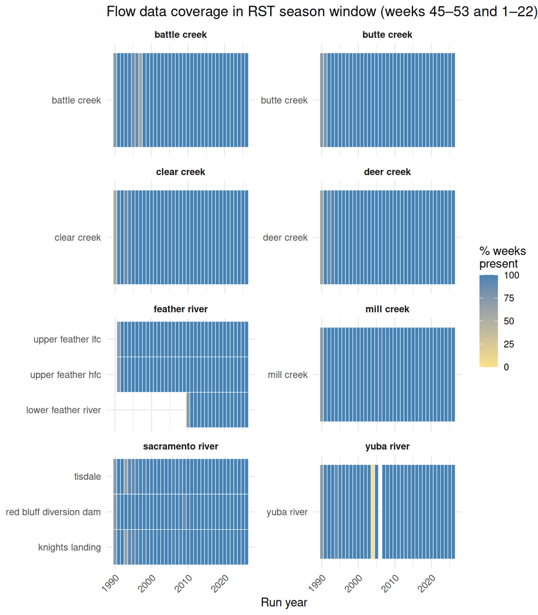

0 gap(s) and 24 extended gap(s) flagged.

## Check 3 (error): Flow — Zero or Negative Values

Flag stream/run_years with any flow value ≤ 0 in the RST season window. Zero flow during RST season is almost certainly a sensor or data issue.

```r
flow_window_all <- flow_data |>
  filter(week %in% RST_WEEKS) |>
  group_by(stream, site_group, run_year) |>
  summarise(
    n_evaluated = n(),
    n_failed    = sum(value <= 0),
    min_value   = min(value),
    .groups     = "drop"
  )

zero_flow <- flow_window_all |> filter(n_failed > 0)

new_zero_flow <- log_issues(
  zero_flow |>
    mutate(
      site        = site_group,
      data_type   = "flow",
      issue_type  = "implausible_value",
      field       = "value",
      severity    = "critical",
      alert_level = "error",
      n_records   = n_failed,
      description = glue("{n_failed} week(s) with flow <= 0 (min = {min_value} cfs) during RST season window in run year {run_year} for {stream}")
    )
)
```

```
  No issues detected for this check.
```

No zero or negative flow values detected.

## Check 4 (warning): Temperature — Implausible Values

Flag stream/run_years with any weekly mean temperature outside the plausible range (< −5°C or > 35°C).

```r
temp_impl_all <- temp_data |>
  group_by(stream, site_group, run_year) |>
  summarise(
    n_evaluated = n(),
    n_failed    = sum(value < -5 | value > 35),
    min_temp    = round(min(value), 1),
    max_temp    = round(max(value), 1),
    .groups     = "drop"
  )

temp_impl <- temp_impl_all |> filter(n_failed > 0)

new_temp_impl <- log_issues(
  temp_impl |>
    mutate(
      site        = site_group,
      data_type   = "flow",
      issue_type  = "implausible_value",
      # NOTE: field is "temperature" (not "value") so this doesn't collide in
      # the qc_log dedup key with the zero/negative flow check above, which
      # also uses issue_type = "implausible_value" for the same data_type.
      field       = "temperature",
      severity    = "critical",
      alert_level = "warning",
      n_records   = n_failed,
      description = glue("{n_failed} weekly temperature record(s) outside [-5, 35]°C in run year {run_year} for {stream}. Range: [{min_temp}, {max_temp}]°C")
    )
)
```

```
  No issues detected for this check.
```

```
Warning: Removed 2 rows containing non-finite outside the scale range
(`stat_bin()`).
```

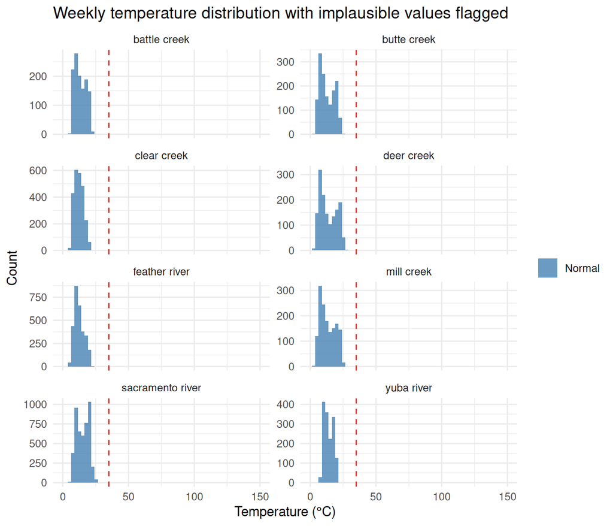

No implausible temperature values detected.

## Issues Logged This Run

```
No new issues logged this run.
```

### All Open Flow Issues

| log_id | date_identified | stream | site | run_year | issue_type | field | severity | alert_level | description | reviewer_notes |
| --- | --- | --- | --- | --- | --- | --- | --- | --- | --- | --- |
| flow__battle_creek__battle_creek__1991__extended_gap__week | 2026-08-12 | battle creek | battle creek | 1991 | extended_gap | week | critical | warning | 9 consecutive RST window weeks missing flow data in run year 1991 for battle creek (9 total missing weeks) |  |
| flow__battle_creek__battle_creek__1997__extended_gap__week | 2026-08-12 | battle creek | battle creek | 1997 | extended_gap | week | critical | warning | 9 consecutive RST window weeks missing flow data in run year 1997 for battle creek (12 total missing weeks) |  |
| flow__butte_creek__butte_creek__1991__extended_gap__week | 2026-08-12 | butte creek | butte creek | 1991 | extended_gap | week | critical | warning | 9 consecutive RST window weeks missing flow data in run year 1991 for butte creek (9 total missing weeks) |  |
| flow__clear_creek__clear_creek__1991__extended_gap__week | 2026-08-12 | clear creek | clear creek | 1991 | extended_gap | week | critical | warning | 9 consecutive RST window weeks missing flow data in run year 1991 for clear creek (9 total missing weeks) |  |
| flow__deer_creek__deer_creek__1991__extended_gap__week | 2026-08-12 | deer creek | deer creek | 1991 | extended_gap | week | critical | warning | 9 consecutive RST window weeks missing flow data in run year 1991 for deer creek (9 total missing weeks) |  |
| flow__feather_river__lower_feather_river__2010__extended_gap__week | 2026-08-12 | feather river | lower feather river | 2010 | extended_gap | week | critical | warning | 9 consecutive RST window weeks missing flow data in run year 2010 for feather river (9 total missing weeks) |  |
| flow__feather_river__upper_feather_hfc__1991__extended_gap__week | 2026-08-12 | feather river | upper feather hfc | 1991 | extended_gap | week | critical | warning | 9 consecutive RST window weeks missing flow data in run year 1991 for feather river (9 total missing weeks) |  |
| flow__feather_river__upper_feather_lfc__1991__extended_gap__week | 2026-08-12 | feather river | upper feather lfc | 1991 | extended_gap | week | critical | warning | 9 consecutive RST window weeks missing flow data in run year 1991 for feather river (9 total missing weeks) |  |
| flow__mill_creek__mill_creek__1991__extended_gap__week | 2026-08-12 | mill creek | mill creek | 1991 | extended_gap | week | critical | warning | 9 consecutive RST window weeks missing flow data in run year 1991 for mill creek (9 total missing weeks) |  |
| flow__sacramento_river__knights_landing__1991__extended_gap__week | 2026-08-12 | sacramento river | knights landing | 1991 | extended_gap | week | critical | warning | 9 consecutive RST window weeks missing flow data in run year 1991 for sacramento river (9 total missing weeks) |  |

[output cut: 22 more lines]